# Code for: Finite mixture models for trajectory analysis of in-hospital routinely laboratory values: application as biomarkers in spinal cord injury patients

Master in Bioinformatics and Biostatistics. Universitat Oberta de Catalunya and Universitat de Barcelona

Abel Torres Espin

2022-05-28

# Setup

## Libraries

```r
library(tidyverse) # for data wrangling and other upper level functionalities
library(DT) # for table functionalities
library(data.table) # to work with big datasets
library(gtsummary) # for summary tables
library(patchwork) # for figures
library(kableExtra) # for more html tables
library(lcmm) # for trajectory modeling
library(parallel) # for parallelization
library(gbmt) # for multy-trajectory modeling as by Nagin
library(caret) # for prediction modeling
```

# The dataset build

Data has been download from [PhysioNet](https://physionet.org/). Both MIMIC databases (DB) are relational DB structured in tables. Documentation about the DB schema can be found [here](https://mimic.mit.edu/docs/).

```
Note that data access need Data Use Agreement with PhysioNet. No data is provided in this document or repository. The code would not run without the data!
```

For cohort selection, we used the International Statistical Classification of Disease (ICD) codes, version 9/10. From the respective DB, the following tables have been download and are locally accessible:

**MIMIC-III** * `PATIENTS`: information demographics for each patient in the DB * `ADMISSIONS`: Unique hospitalizations of each patient in the DB * `DIAGNOSES_ICD`: Hospital assigned diagnoses with ICD codes * `LABEVENTS`: Laboratory measurements for patients * `D_LABITEMS`: dictionary with each laboratory assay metadata * `D_ICD_DIAGNOSES`: definitions for ICDs diagnoses

**MIMIC-IV** * `core/patients`: information demographics for each patient in the DB * `core/admissions`: Unique hospitalizations of each patient in the DB * `hosp/diagnoses_icd`: Hospital assigned diagnoses with ICD codes * `hosp/labevents`: Laboratory measurements for patients * `hosp/d_labitems`: dictionary with each laboratory assay metadata * `hosp/d_icd_diagnoses`: definitions for ICDs diagnoses

## Patient selection

**The inclusion criteria are:**

- Adults
- Acute patients with ICD codes with specification of spinal cord injury (SCI) or spine trauma (vertebral fracture). This include ICD9 codes of the following series (full list can be seen in the appendix)
  - `952`: Spinal cord injury without evidence of spinal bone injury
  - `953`: Injury to nerve roots and spinal plexus
  - `806`: Fracture of vertebral column with spinal cord injury
  - `805`: Fracture of vertebral column without mention of spinal cord injury

*Note*.The list of ICD10 can be seen in the `data/icd10_codes_sci.csv`

In MIMIC diagnostics table, there is one row per diagnostic per patient per hospital admission. Some patients may have more than one hospital admission. We selected the first hospital admission per patient that shows in the DB. From there, we filtered the patients that have presence of selected ICD9/10 codes in their hospital stay.

### Creating ICD9/10 filtering

MIMIC-III/IV uses both ICD9 and 10. For filtering, we created a separated list of ICD9 and ICD10 codes in two .csv files. Here we upload the files and create a character vector with all the codes for the filtering. We append `\\b` in front of each code as this helps with the processes of filtering by regular expressions. `\\b` ensures that each code matches from the **beginning** of the code, preventing middle code mismatches since some times codes are truncated or has extensions.

```r
#From manually created list
icd9_codes_sci<-read.csv('icd9_codes_sci.csv')
icd10_codes_sci<-read.csv('icd10_codes_sci.csv')

#Inclusion codes
icd_scAll_filter<-paste(c(paste0("\\b",unique(icd9_codes_sci$icd9_codes_L1)),
                          paste0("\\b",unique(icd10_codes_sci$icd10_codes_L1))),
                       collapse = "|")

head(icd_scAll_filter)
```

```
## [1] "\\b952|\\b805|\\b953|\\b806|\\bS120|\\bS121|\\bS122|\\bS123|\\bS124|\\bS125|\\bS126|\\bS128|\\bS129|\\bS140|\\bS141|\\bS142|\\bS220|\\bS240|\\bS241|\\bS242|\\bS320|\\bS321|\\bS340|\\bS341|\\bS342|\\bS343"
```

#### MIMIC III

*Not computed on time of knitting*

```r
## read data
mimic3_diagnostic<-read.csv('data/MIMICIII/DIAGNOSES_ICD.csv.gz')
mimic3_admissions<-read.csv('data/MIMICIII/ADMISSIONS.csv.gz')
mimic3_patients<-read.csv('data/MIMICIII/PATIENTS.csv.gz')

mimic3_patients<-mimic3_patients%>%
  mutate(SUBJECT_ID = as.character(SUBJECT_ID))%>%
  select(-ROW_ID)

## Patients with diagnostics related to ICD9 codes
mimic3_diagnostic_sci9<-mimic3_diagnostic%>%
  filter(str_detect(ICD9_CODE,icd_scAll_filter))

## Total number of admissions at mimic
mimic3_sci_hadm_id<-unique(mimic3_diagnostic_sci9$HADM_ID)

## Pulling data for all id patients together
mimic3_diagnostic_sci9<-mimic3_diagnostic%>%
  filter(HADM_ID%in%as.numeric(mimic3_sci_hadm_id))%>%#Filter by ICD9 sci relevant
  mutate(SUBJECT_ID = as.character(SUBJECT_ID))%>%
  arrange(SEQ_NUM, SUBJECT_ID)%>%
  group_by(HADM_ID)%>%
  mutate(n_codes = n())%>%
  summarise_all(.funs = function (x){
    paste(unique(x), collapse = " | ")
  })%>%
  select(-ROW_ID)

# Number of patients with more than one hospital admission
sum(duplicated(mimic3_diagnostic_sci9$SUBJECT_ID))
```

```r
mimic3_filtered<-mimic3_admissions%>%
  mutate(SUBJECT_ID=as.character(SUBJECT_ID))%>%
  right_join(mimic3_diagnostic_sci9)%>%
  left_join(mimic3_patients)%>%
  arrange(EDREGTIME)%>% #arrange the dataframe by admission time
  group_by(SUBJECT_ID)%>%#perform operation per subject
  mutate(n_hadm = n())%>% #enumerate the order of the admission per patient
  filter(n_hadm == 1, EDREGTIME !="")%>% #select the first admission
  select(-ROW_ID)

# mimic3_filtered%>%
#   DT::datatable()
```

**Save data object**

```r
saveRDS(mimic3_filtered, file = "data/MIMICIII/mimic3_filtered.Rds")
```

**Calculating age in MIMIC-III**

MIMIC-III does not provide age. Dates for each patient are shifted for privacy reasons, but temporal consistency is maintained. We can calculate age at hospital arrival by subtracting date of birth from arrival time (ED registery time).

```r
mimic3_filtered<-readRDS("data/MIMICIII/mimic3_filtered.Rds")

mimic3_filtered<-mimic3_filtered%>%
  mutate(DOB = strptime(DOB, format = "%Y-%m-%d %H:%M:%S"),
         EDREGTIME = strptime(EDREGTIME,format = "%Y-%m-%d %H:%M:%S"),
         age = abs(as.numeric(difftime(DOB, EDREGTIME, units = "days"))),
         age = floor(age/365),
         age = ifelse(age>=300, 89, age)) ## shift from >= 300 to 89

summary(mimic3_filtered$age)
```

```
##    Min. 1st Qu.  Median    Mean 3rd Qu.    Max.
##   15.00   35.00   52.00   52.97   72.00   89.00
```

The number of unique patients in the MIMIC-III dataset is 1194

#### MIMIC IV

*Not computed on time of knitting*

```r
## read data
mimic4_diagnostic<-read.csv('data/MIMICIV/diagnoses_icd.csv.gz')
mimic4_admissions<-read.csv('data/MIMICIV/admissions.csv.gz')
mimic4_patients<-read.csv('data/MIMICIV/patients.csv.gz')

mimic4_patients<-mimic4_patients%>%
  mutate(subject_id = as.character(subject_id))

## Patients with diagnostics related to ICD9 codes
mimic4_diagnostic_sc<-mimic4_diagnostic%>%
  filter(str_detect(icd_code,icd_scAll_filter))

## Total number of admissions at mimic
mimic4_sci_hadm_id<-unique(mimic4_diagnostic_sc$hadm_id)

## Pulling data for all id patients together
mimic4_diagnostic_sc<-mimic4_diagnostic%>%
  filter(hadm_id%in%as.numeric(mimic4_sci_hadm_id))%>%#Filter by ICD9/10 sci relevant
  mutate(subject_id = as.character(subject_id))%>%
  arrange(seq_num, subject_id)%>%
  group_by(hadm_id)%>%
  mutate(n_codes = n())%>%
  summarise_all(.funs = function (x){
    paste(unique(x), collapse = " | ")
  })

# Number of patients with more than one hospital admission
sum(duplicated(mimic4_diagnostic_sc$subject_id))
```

488 patients had more than one hospital admission. We will select the first admission using the information of the admission table.

```r
mimic4_filtered<-mimic4_admissions%>%
  mutate(subject_id = as.character(subject_id))%>%
  right_join(mimic4_diagnostic_sc)%>%
  left_join(mimic4_patients)%>%
  arrange(edregtime)%>% #arrange the dataframe by admission time
  group_by(subject_id)%>%#perform operation per subject
  mutate(n_hadm = 1:n())%>% #enumerate the order of the admission per patient
  filter(n_hadm == 1, edregtime !="") #select the first admission

# mimic4_filtered%>%
#   DT::datatable()
```

**Save data object**

```r
saveRDS(mimic4_filtered, file = "data/MIMICIV/mimic4_filtered.Rds")
```

**Patient Age**

In MIMIC-IV, exact age is not provided and it is cannot be computed. There is an “anchor” age, that provides an estimate of the age at admission on a range of 3 years.

```r
mimic4_filtered<-readRDS("data/MIMICIV/mimic4_filtered.Rds")
summary(mimic4_filtered$anchor_age)
```

```
##    Min. 1st Qu.  Median    Mean 3rd Qu.    Max.
##   18.00   49.00   67.00   63.55   82.00   91.00
```

The number of unique patients in the MIMIC-IV dataset is 4529

#### Join both MIMIC

Here we join both datasets with the filtered patient information. One problem at joining both datasets is that during the transition between MIMIC-III and MIMIC-IV, patient identification changed, and both datasets may overlap on a subset of patients. MIMIC-III has patients from 2001 to 2012, MIMIC-IV has patients from 2008 to 2019. In order to prevent patient duplication, we decided to filter out MIMIC-IV patients that contains the same ICD sequence (order, codes and length).

```r
sum(mimic4_filtered$icd_code%in%mimic3_filtered$ICD9_CODE)
```

```
## [1] 515
```

```r
mimic4_filtered<-mimic4_filtered[which(!mimic4_filtered$icd_code%in%mimic3_filtered$ICD9_CODE),]
```

This reduces the MIMIC-IV in 515 patients, all from the overlapping years

**Joining**

```r
colnames(mimic3_filtered)
```

```
##  [1] "SUBJECT_ID"           "HADM_ID"              "ADMITTIME"
##  [4] "DISCHTIME"            "DEATHTIME"            "ADMISSION_TYPE"
##  [7] "ADMISSION_LOCATION"   "DISCHARGE_LOCATION"   "INSURANCE"
## [10] "LANGUAGE"             "RELIGION"             "MARITAL_STATUS"
## [13] "ETHNICITY"            "EDREGTIME"            "EDOUTTIME"
## [16] "DIAGNOSIS"            "HOSPITAL_EXPIRE_FLAG" "HAS_CHARTEVENTS_DATA"
## [19] "SEQ_NUM"              "ICD9_CODE"            "n_codes"
## [22] "GENDER"               "DOB"                  "DOD"
## [25] "DOD_HOSP"             "DOD_SSN"              "EXPIRE_FLAG"
## [28] "n_hadm"               "age"
```

```r
colnames(mimic4_filtered)
```

```
##  [1] "subject_id"           "hadm_id"              "admittime"
##  [4] "dischtime"            "deathtime"            "admission_type"
##  [7] "admission_location"   "discharge_location"   "insurance"
## [10] "language"             "marital_status"       "ethnicity"
## [13] "edregtime"            "edouttime"            "hospital_expire_flag"
## [16] "seq_num"              "icd_code"             "icd_version"
## [19] "n_codes"              "gender"               "anchor_age"
## [22] "anchor_year"          "anchor_year_group"    "dod"
## [25] "n_hadm"
```

Notice that the variable names are not identical between both, so we had to do some cleaning and harmonization:

```r
colnames(mimic3_filtered)<-str_to_lower(colnames(mimic3_filtered))
colnames(mimic3_filtered)[20]<-"icd_code"

mimic3_filtered$admittime<-strptime(mimic3_filtered$admittime, format = "%Y-%m-%d %H:%M:%S")
mimic3_filtered$edregtime<-strptime(mimic3_filtered$edregtime, format = "%Y-%m-%d %H:%M:%S")

colnames(mimic4_filtered)[21]<-"age"
mimic4_filtered$admittime<-strptime(mimic4_filtered$admittime, format = "%Y-%m-%d %H:%M:%S")
mimic4_filtered$edregtime<-strptime(mimic4_filtered$edregtime, format = "%Y-%m-%d %H:%M:%S")

mimic3_filtered$dataset<-"MIMIC-III"
mimic4_filtered$dataset<-"MIMIC-IV"

vars_to_keep<-colnames(mimic3_filtered)[colnames(mimic3_filtered)%in%colnames(mimic4_filtered)]

mimic_patients_all<-rbind(mimic3_filtered[,vars_to_keep],
                          mimic4_filtered[,vars_to_keep])

table(mimic_patients_all$dataset)
```

```
##
## MIMIC-III  MIMIC-IV
##      1194      4014
```

```r
length(unique(mimic_patients_all$subject_id))
```

```
## [1] 5208
```

### Extraction of laboratory analytes data

Laboratory data table in both MIMIC-III and IV are too big to work with them on memory. For that we read them in chunks to filter the patients selected above. In addition, the files have been downloaded compressed. To reduce computational burden while reading the file in chunks, we decompressed the files first.

#### MIMIC-III

**Not run during knitting**

```r
# Unzip the file. Do only once
# R.utils::gunzip("data/MIMICIII/LABEVENTS.csv.gz")

### Load the files
mimic3_lab_path<-"data/MIMICIII/LABEVENTS.csv"
mimic3_lab_header<-read.csv(mimic3_lab_path,
                             nrows = 1, header = F)
##header
mimic3_lab_header

# Function to subset each chunk
mimic3_filter <- function(x, pos){
  subset(x, HADM_ID %in% mimic_patients_all$hadm_id)
}

# Load and filter labs by chunks
mimic3_lab_sc<-read_csv_chunked(mimic3_lab_path,
                 DataFrameCallback$new(mimic3_filter), chunk_size = 50000)
```

##### add lab item info

**Not run during knitting**

```r
### lab items
mimic3_lab_items<-read.csv("data/MIMICIII/D_LABITEMS.csv.gz")

mimic3_lab_sc<-mimic3_lab_sc%>%
  select(-ROW_ID)%>%
  left_join(mimic3_lab_items)%>%
  select(-ROW_ID)
```

**Save the data**

```r
saveRDS(mimic3_lab_sc, file = "data/MIMICIII/mimic3_lab_sc.Rds")
```

#### MIMIC-IV

**Not run during knitting**

```r
# Unzip the file. Do only once
# R.utils::gunzip("data/MIMICIV/labevents.csv.gz")

### Load the files
mimic4_lab_path<-"data/MIMICIV/labevents.csv"
mimic4_lab_header<-read.csv(mimic4_lab_path,
                             nrows = 1, header = F)
##header
mimic4_lab_header

# Function to subset each chunk
mimic4_filter <- function(x, pos){
  subset(x, hadm_id %in% mimic_patients_all$hadm_id)
}

# Load and filter labs by chunks
mimic4_lab_sc<-read_csv_chunked(mimic4_lab_path,
                 DataFrameCallback$new(mimic4_filter), chunk_size = 50000)
```

##### add lab item info

**Not run during knitting**

```r
### lab items
mimic4_lab_items<-read.csv("data/MIMICIV/d_labitems.csv.gz")

mimic4_lab_sc<-mimic4_lab_sc%>%
  left_join(mimic4_lab_items)
```

**Save the data**

```r
saveRDS(mimic4_lab_sc, file = "data/MIMICIV/mimic4_lab_sc.Rds")
```

#### Join both MIMIC lab data

```r
## read lab information
mimic3_lab_sc<-readRDS("data/MIMICIII/mimic3_lab_sc.Rds")
mimic3_lab_items<-read.csv("data/MIMICIII/D_LABITEMS.csv.gz")

colnames(mimic3_lab_items)<-str_to_lower(colnames(mimic3_lab_items))
mimic3_lab_items$row_id<-NULL

mimic4_lab_sc<-readRDS("data/MIMICIV/mimic4_lab_sc.Rds")
mimic4_lab_items<-read.csv("data/MIMICIV/d_labitems.csv.gz")

## Transform mimic III column names to lowercase
colnames(mimic3_lab_sc)<-str_to_lower(colnames(mimic3_lab_sc))

## Add dataset origin variable
mimic3_lab_sc$dataset<-"MIMIC-III"
mimic4_lab_sc$dataset<-"MIMIC-IV"

## Keep variables that are common between both dataset
var_labs_to_keep<-colnames(mimic3_lab_sc)[colnames(mimic3_lab_sc)%in%colnames(mimic4_lab_sc)]

#Join both datasets
mimic_labs_all<-rbind(mimic3_lab_sc[,var_labs_to_keep],
                      mimic4_lab_sc[,var_labs_to_keep])

mimic_labs_all$subject_id<-as.character(mimic_labs_all$subject_id)
```

The time for each item in MIMIC are shifted. We calculated the time of values respect to hospital arrival. For that, we need to join the labs data with the patient data.

```r
mimic_labs_all<-mimic_patients_all%>%
  select(subject_id, hadm_id, edregtime)%>%
  right_join(mimic_labs_all)%>%
  mutate(charttime = strptime(charttime, format = "%Y-%m-%d %H:%M:%S"),
         time_minutes = as.numeric(difftime(charttime,edregtime, units = "min")))
```

## Extract patient characteristics

The following section of the code harmonize the selected patient characteristics between both MIMIC datasets.

There are differences in the coding of some variables across datasets. We recoded insurance and ethnicity to match. For ethnicity, we collapsed to the modeling set of levels from MIMIC-IV, for insurance, it is not clear whether *Other* in IV includes *Private and self Pay*. We collapsed/recoded as following: Government -> other government, Private, self Pay -> Other

```r
mimic_patients_all<-mimic_patients_all%>%
  mutate(
    ethnicity = case_when(
      str_detect(ethnicity, "ASIAN")~"ASIAN",
      str_detect(ethnicity, "BLACK")~"BLACK/AFRICAN AMERICAN",
      str_detect(ethnicity, "HISPANIC")~"HISPANIC/LATINO",
      str_detect(ethnicity, "DECLINED")~NA_character_,
      str_detect(ethnicity, "UNKNOWN|Unknown")~NA_character_,
      is.na(ethnicity)~NA_character_,
      str_detect(ethnicity, "WHITE")~"WHITE",
      str_detect(ethnicity, "OTHER")~"OTHER",
      str_detect(ethnicity, "MULTI")~"MULTI RACE/ETHNICITY"),
    insurance = case_when(
      str_detect(insurance, "Gov")~"Other Government",
      str_detect(insurance, "Private")~"Other",
      str_detect(insurance, "Self Pay")~"Other",
      TRUE~insurance)
  )
```

For encounter characteristics, we will include: admission type, admission location, discharge location. There were clear differences in the names of the levels between datasets. We harmonized these to the minimal information possible.

```r
mimic_patients_all<-mimic_patients_all%>%
  mutate(
    admission_type = case_when(
      str_detect(admission_type, "EMER")~"EMERGENCY",
      str_detect(admission_type, "EU")~"EMERGENCY",
      str_detect(admission_type, "OBSER")~"OBSERVATION",
      str_detect(admission_type, "ELECTIVE")~"ELECTIVE",
      str_detect(admission_type, "SURGICAL")~"ELECTIVE",
      TRUE~admission_type),
    admission_location = case_when(
      str_detect(admission_location, "CLINIC")~"CLINIC REFERRAL",
      str_detect(admission_location, "PHYS")~"CLINIC REFERRAL",
      str_detect(admission_location, "EMER")~"EMERGENCY ROOM",
      str_detect(admission_location, "INFO")~NA_character_,
      str_detect(admission_location, "TRANS.+HOSP")~"TRANSFER FROM HOSP",
      str_detect(admission_location, "SKILLED")~"TRANSFER FROM SNF",
      TRUE~admission_location),
    discharge_location = case_when(
      discharge_location==""~NA_character_,
      str_detect(discharge_location, "DIED")~"DIED",
      str_detect(discharge_location, "DEAD")~"DIED",
      str_detect(discharge_location, "DISC-TRAN")~"TRANSFER TO OTHER",
      str_detect(discharge_location, "OTHER")~"TRANSFER TO OTHER",
      str_detect(discharge_location, "PSYCH")~"TRANSFER TO OTHER",
      str_detect(discharge_location, "^HOME")~"HOME/HOSPICE",
      str_detect(discharge_location, "HOSPICE")~"HOME/HOSPICE",
      str_detect(discharge_location, "REHAB")~"REHAB",
      str_detect(discharge_location, "SKILLED")~"SKILLED NURSING FACILITY",
      str_detect(discharge_location, "SNF")~"SKILLED NURSING FACILITY",
      str_detect(discharge_location, "ASSISTED LIVING")~"SKILLED NURSING FACILITY",
      str_detect(discharge_location, "ADVI")~"AGAINST ADVICE",
      str_detect(discharge_location, "LONG TERM")~"LONG TERM CARE",
      str_detect(discharge_location, "SHORT TERM")~"SHORT TERM CARE",
      TRUE~discharge_location)
    )
```

#### Filter of patients from Emergency only

With the variables harmonized, we filtered patients admitted to the hospital by emergency.

```r
mimic_patients_all<-mimic_patients_all%>%
  filter(admission_type=="EMERGENCY")

table(mimic_patients_all$dataset)
```

```
##
## MIMIC-III  MIMIC-IV
##      1193      2955
```

#### Cohort definition

We defined three different cohorts depending on their ICD codes. We distinguish between:

- `Spine Trauma`. Spine trauma with no mention of SCI
- `SCI_Fracture`. SCI with spine trauma
- `SCI_noFracture`. SCI with no mention of spine trauma

```r
### Determine patient group
icd_fracture<-"\\b805|\\bS120|\\bS121|\\bS122|\\bS123|\\bS124|\\bS125|\\bS126|\\bS128|\\bS129|\\bS220|\\bS320|\\bS321"

icd_sci<-"\\bS141|\\bS140|\\bS142|\\bS240|\\bS241|\\bS242|\\bS340|\\bS341|\\bS342|\\bS343"

mimic_patients_all<-mimic_patients_all%>%
  group_by(subject_id)%>%
  mutate(cohort_group=case_when(
    str_detect(icd_code, "\\b952|\\b953")&
      !str_detect(icd_code, paste0(icd_fracture,"|\\b806"))~"SCI_noFracture",
    str_detect(icd_code, paste0(icd_sci,"|\\b952|\\b953"))&
      str_detect(icd_code, paste0(icd_fracture,"|\\b806"))~"SCI_Fracture",
    str_detect(icd_code, "\\b806")~"SCI_Fracture",
    str_detect(icd_code, icd_sci)&
      !str_detect(icd_code, paste0(icd_fracture,"|\\b806"))~"SCI_noFracture",
    str_detect(icd_code, icd_fracture)&
      !str_detect(icd_code, paste0(icd_sci,"|\\b952|\\b953|\\b806"))~"Spine Trauma",
    TRUE~"test"
  ))

table(mimic_patients_all$cohort_group)
```

```
##
##   SCI_Fracture SCI_noFracture   Spine Trauma
##            422            175           3551
```

## Analyte Exploratory Data Analysis (EDA)

### Lab analytes summaries

One issue we observed during the exploration of the data is that not all patients has data for all lab assay, and that the time for those assays after injury vary. In order to have a better sense of the data, we are going to summarize it.

```
Note on LOINC codes. LOINC stands for Logical Observation Identifiers Names and Codes, and it is a clinical terminology standard for laboratory test and results, which allow us to now detailed information of the extracted lab test.
```

```r
## Filter labs data based on cohort selection
mimic_labs_all<-mimic_labs_all%>%
  filter(hadm_id%in%mimic_patients_all$hadm_id)

## summaries
summary_labs<-mimic_labs_all%>%
  mutate(value = as.numeric(value),
         hadm_id = as.character(hadm_id))%>%
  filter(!is.na(value))%>%
  group_by(itemid, hadm_id)%>%
  summarise(time_points=n())%>%
  group_by(itemid)%>%
  summarise(mean_time_points=mean(time_points),max_time_points = max(time_points), n_patients=n())%>%
  mutate(per_patients=n_patients/length(unique(mimic_labs_all$hadm_id)))%>%
  left_join(mimic3_lab_items)%>%
  left_join(mimic4_lab_items)

summary_labs%>%
  .[complete.cases(.),]%>%
  arrange(desc(per_patients))%>%
  select(itemid,loinc_code, label, fluid, category, per_patients)%>%
  kbl(digits = 2)%>%
  kable_paper()%>%
  save_kable(file = "tables/summary_labs.html")

addmargins(table(summary_labs$fluid, summary_labs$category, useNA = "always"))%>%
  kbl()%>%
  kable_paper()
```

|  | Blood Gas | Chemistry | Hematology | NA | Sum |
| --- | --- | --- | --- | --- | --- |
| Ascites | 0 | 9 | 13 | 0 | 22 |
| Blood | 24 | 104 | 71 | 0 | 199 |
| Cerebrospinal Fluid (CSF) | 0 | 3 | 13 | 0 | 16 |
| Joint Fluid | 0 | 1 | 11 | 0 | 12 |
| Other Body Fluid | 1 | 9 | 14 | 0 | 24 |
| Pleural | 0 | 8 | 15 | 0 | 23 |
| Urine | 0 | 27 | 20 | 0 | 47 |
| NA | 0 | 0 | 0 | 70 | 70 |
| Sum | 25 | 161 | 157 | 70 | 413 |

**Summary**

We see from the table that a lot of lab assays have been performed in very little number of patients. For consistency across datasets and proof of concept, we selected assays that are found across most patients.

**Most common 20 assays**

```r
summary_labs%>%
  arrange(desc(per_patients))%>%
  head(n=20)%>%
  kableExtra::kbl()%>%
  kable_classic()
```

| itemid | mean_time_points | max_time_points | n_patients | per_patients | label | fluid | category | loinc_code |
| --- | --- | --- | --- | --- | --- | --- | --- | --- |
| 51221 | 9.681284 | 153 | 3489 | 0.9770372 | Hematocrit | Blood | Hematology | 4544-3 |
| 51301 | 8.166763 | 152 | 3472 | 0.9722767 | White Blood Cells | Blood | Hematology | 804-5 |
| 51222 | 8.159608 | 152 | 3471 | 0.9719966 | Hemoglobin | Blood | Hematology | 718-7 |
| 51248 | 8.124460 | 152 | 3471 | 0.9719966 | MCH | Blood | Hematology | 785-6 |
| 51249 | 8.126765 | 152 | 3471 | 0.9719966 | MCHC | Blood | Hematology | 786-4 |
| 51250 | 8.125036 | 152 | 3471 | 0.9719966 | MCV | Blood | Hematology | 787-2 |
| 51277 | 8.108614 | 152 | 3471 | 0.9719966 | RDW | Blood | Hematology | 788-0 |
| 51279 | 8.125036 | 152 | 3471 | 0.9719966 | Red Blood Cells | Blood | Hematology | 789-8 |
| 51265 | 8.284726 | 228 | 3470 | 0.9717166 | Platelet Count | Blood | Hematology | 777-3 |
| 50912 | 8.403175 | 189 | 3465 | 0.9703164 | Creatinine | Blood | Chemistry | 2160-0 |
| 51006 | 8.397691 | 189 | 3465 | 0.9703164 | Urea Nitrogen | Blood | Chemistry | 3094-0 |
| 50971 | 8.796458 | 325 | 3444 | 0.9644357 | Potassium | Blood | Chemistry | 2823-3 |
| 50902 | 8.428655 | 324 | 3441 | 0.9635956 | Chloride | Blood | Chemistry | 2075-0 |
| 50983 | 8.676547 | 326 | 3441 | 0.9635956 | Sodium | Blood | Chemistry | 2951-2 |
| 50868 | 8.192084 | 185 | 3436 | 0.9621955 | Anion Gap | Blood | Chemistry | 1863-0 |
| 50882 | 8.209546 | 185 | 3436 | 0.9621955 | Bicarbonate | Blood | Chemistry | 1963-8 |
| 50931 | 8.260553 | 186 | 3435 | 0.9619154 | Glucose | Blood | Chemistry | 2345-7 |
| 50960 | 8.240506 | 143 | 3239 | 0.9070288 | Magnesium | Blood | Chemistry | 2601-3 |
| 50893 | 7.756211 | 142 | 3220 | 0.9017082 | Calcium, Total | Blood | Chemistry | 2000-8 |
| 50970 | 7.884771 | 142 | 3211 | 0.8991879 | Phosphate | Blood | Chemistry | 2777-1 |

Let’s take a look at the most common analytes with some spaghetti plots and density plots. We define the set of the 20 most common analytes as the *modeling set*

```r
item_id<-summary_labs%>%
  arrange(desc(per_patients))%>%
  head(n=20)%>%
  select(itemid)%>%
  unlist()

## define the modeling set
mimic_modeling_set<-mimic_labs_all%>%
  filter(itemid%in%item_id)%>%
  filter(subject_id%in%mimic_patients_all$subject_id)
```

The time scale for MIMIC is in minutes. To have a better idea of the time interval between measures for each analyte, we summarize the time component.

```r
## Summary table for the time frequency
time_frequency<-mimic_modeling_set%>%
  group_by(subject_id, label)%>%
  summarise(time_freq = mean(abs(diff(time_minutes)), na.rm = T))%>%
  group_by(label)%>%
  summarise(min = min(time_freq, na.rm = T),
            Q1 = quantile(time_freq, probs = 0.25, na.rm = T),
            median = median(time_freq, na.rm = T),
            Q3 = quantile(time_freq, probs = 0.75, na.rm = T),
            max = max(time_freq, na.rm = T))

time_frequency%>%
  kableExtra::kbl()%>%
  kable_classic()
```

| label | min | Q1 | median | Q3 | max |
| --- | --- | --- | --- | --- | --- |
| Anion Gap | 55 | 1181.528 | 1477.917 | 2407.500 | 23300.64 |
| Bicarbonate | 55 | 1162.600 | 1457.750 | 2219.500 | 23315.31 |
| Calcium, Total | 55 | 1216.562 | 1472.100 | 2346.088 | 24195.43 |
| Chloride | 55 | 1145.000 | 1453.000 | 2181.500 | 22938.41 |
| Creatinine | 51 | 1111.986 | 1441.056 | 2169.036 | 23418.87 |
| Glucose | 55 | 1310.312 | 1793.500 | 2945.750 | 70767.59 |
| Hematocrit | 51 | 950.000 | 1387.471 | 1925.000 | 25840.04 |
| Hemoglobin | 51 | 1110.000 | 1443.333 | 2144.231 | 26464.14 |
| Magnesium | 55 | 1192.139 | 1464.000 | 2243.154 | 24149.69 |
| MCH | 51 | 1118.000 | 1443.600 | 2152.500 | 26464.14 |
| MCHC | 51 | 1118.000 | 1443.500 | 2152.500 | 26448.42 |
| MCV | 51 | 1125.500 | 1445.000 | 2176.667 | 26412.60 |
| Phosphate | 55 | 1223.286 | 1487.167 | 2324.469 | 24184.06 |
| Platelet Count | 51 | 1154.000 | 1460.000 | 2235.000 | 26116.24 |
| Potassium | 55 | 1189.208 | 1505.750 | 2351.050 | 24841.37 |
| RDW | 51 | 1120.303 | 1443.536 | 2142.933 | 27705.42 |
| Red Blood Cells | 51 | 1120.087 | 1443.333 | 2142.500 | 27733.32 |
| Sodium | 55 | 1179.350 | 1481.750 | 2340.692 | 24751.89 |
| Urea Nitrogen | 51 | 1109.194 | 1440.000 | 2135.896 | 24321.81 |
| White Blood Cells | 51 | 1125.359 | 1447.500 | 2177.500 | 29743.08 |

We work the rest of this analysis in fractions of days instead of minutes

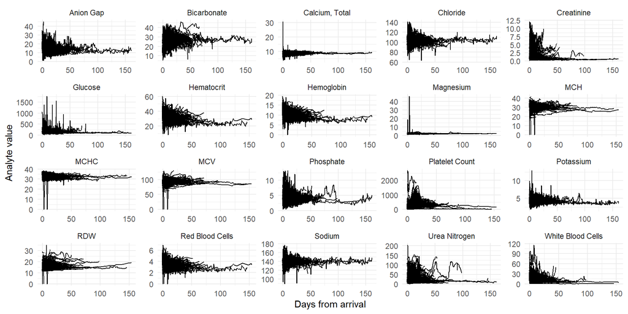

```r
mimic_modeling_set%>%
  ggplot(aes(floor(time_minutes/1440), valuenum))+
  geom_line(aes(group=subject_id))+
  facet_wrap(~label, scales = "free")+
  xlab("Days from arrival")+
  ylab("Analyte value")+
  theme_minimal()
```

```r
ggsave("figures/modeling_set_labs_raw.png", height = 6, width = 10)
```

This next chunk takes the count of the number of patients with data per day

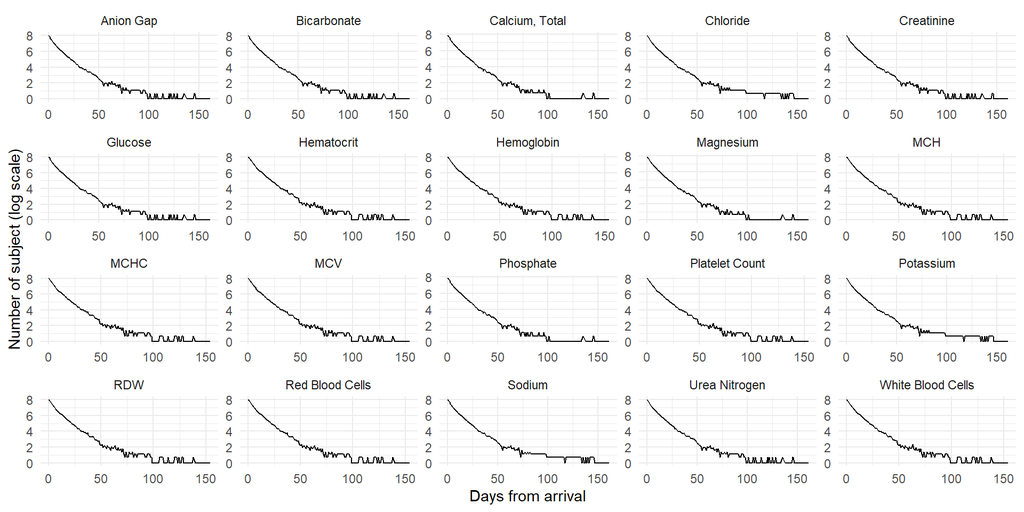

```r
mimic_modeling_set%>%
  mutate(time_days = floor(time_minutes/1440))%>%
  group_by(time_days, label, subject_id)%>%
  summarise(mean_values = mean (valuenum, na.rm = T))%>%
  group_by(time_days, label)%>%
  summarise(count = n())%>%
  filter(time_days>=0)%>%
  ggplot(aes(time_days, log(count)))+
  geom_line()+
  facet_wrap(~label, scales = "free")+
  xlab("Days from arrival")+
  ylab("Number of subject (log scale)")+
  theme_minimal()
```

```r
ggsave("figures/modeling_set_labs_log_subjects.png", height = 6, width = 10)
```

Marginal densities of the modeling set

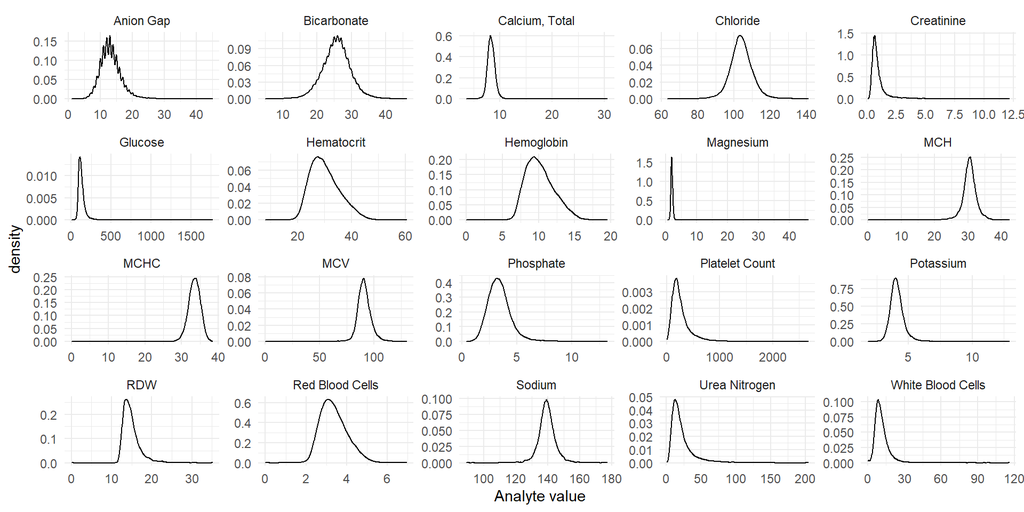

```r
mimic_modeling_set%>%
  ggplot(aes(valuenum))+
  geom_density()+
  facet_wrap(~label, scales = "free")+
  xlab("Analyte value")+
  theme_minimal()
```

```r
ggsave("figures/modeling_set_labs_density.png", height = 6, width = 10)
```

### Analyte data cleaning

We can see the presence of potential outliers as well as patients that have data for a long period of time.

To deal with outliers that may be indicative of wrong readings, we filter all the extreme values (unwanted data, anomalies). Since we don’t want to take potential real values away even if they are extreme, we apply a very permissive filter. we could use $1.5*IQR$ inner fence method suggested by John Tukey (also known as the Tukey’s rule), however, it may be quite restrictive in this case, specially with skewed distributions (Seo 2006). There are some functionalities in R to clean time-series data (see fpp2) package, however, this assume equispaced observations in time, which is not the case here. Therefore, for simplicity we apply an heuristic filter followings Tukey’s rule for each subject, but using the deciles instead of the quantiles.

```
Note. Anomaly detection in temporal data is a big topic that we do not explore here
```

```r
mimic_modeling_set<-mimic_modeling_set%>%
  filter(valuenum>0, time_minutes>=0)

## custom function for detecting and deleting extreme values
extreme_deletion<-function(x, prob = c(0.2,0.8), factor = 1.5){
  down<-quantile(x, prob[1])-factor*IQR(x)
  up<-quantile(x, prob[2])+factor*IQR(x)

  x<-ifelse(x>up, NA,x)
  x<-ifelse(x<down, NA,x)

  return(x)
}

mimic_modeling_set<-mimic_modeling_set%>%
  arrange(time_minutes)%>%
  group_by(label, subject_id)%>%
  mutate(value_clean = extreme_deletion(valuenum),
         out = ifelse(is.na(value_clean), 1,0))%>%
  filter(out == 0)
```

### Selecting time window for analysis

Let’s see the distribution of discharge time

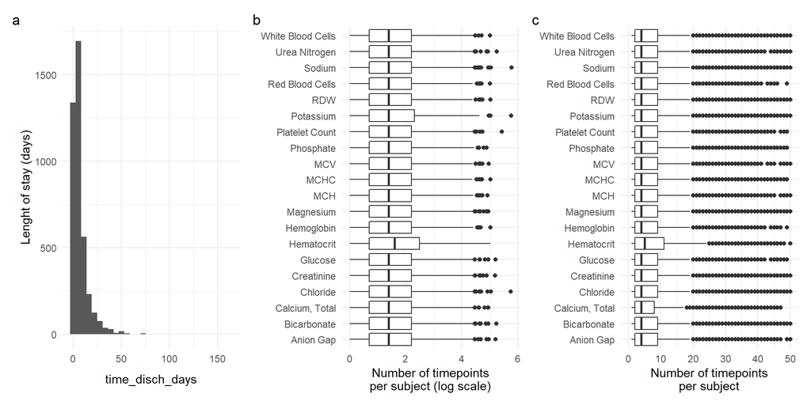

```r
mimic_patients_all<-mimic_patients_all%>%
  mutate(dischtime=strptime(dischtime, format = "%Y-%m-%d %H:%M:%S"),
         time_disch_days=as.numeric(difftime(dischtime, admittime, units = "days")))

los_plot_a<-ggplot(mimic_patients_all, aes(time_disch_days))+
  geom_histogram()+
  ylab("Lenght of stay (days)")+
  theme_minimal()

los_plot_b<-mimic_modeling_set%>%
  group_by(subject_id, label)%>%
  summarise(count = n())%>%
  ggplot(aes(label, log(count)))+
  xlab(NULL)+
  ylab("Number of timepoints\nper subject (log scale)")+
  geom_boxplot()+
  coord_flip()+
  theme_minimal()

los_plot_c<-mimic_modeling_set%>%
  group_by(subject_id, label)%>%
  summarise(count = n())%>%
  ggplot(aes(label, count))+
  xlab(NULL)+
  ylab("Number of timepoints\nper subject")+
  geom_boxplot()+
  coord_flip()+
  theme_minimal()+
  ylim(0, 50)

fig_los<-los_plot_a+los_plot_b+los_plot_c
fig_los<-fig_los+plot_annotation(tag_levels = "a")
fig_los
```

```r
ggsave("figures/modeling_set_los.png", height = 3.5, width = 10)
```

Given the above data, we analyzed data no longer than 21 days from hospital arrival (3 first weeks).

```r
mimic_modeling_set<-mimic_modeling_set%>%
  mutate(time_days=time_minutes/1440)%>%
  filter(time_days<=21)
```

In addition, we only considered subjects with at least 3 measures

```r
time_mimic_labs_sum<-mimic_modeling_set%>%
  group_by(subject_id, label)%>%
  summarise(n_times=n())

mimic_labs_hadm_filter<-time_mimic_labs_sum%>%
  filter(n_times>2)

## Filter based on subjects with more than 2 timepoints
mimic_modeling_set_f<-mimic_modeling_set%>%
  filter(subject_id%in%unique(mimic_labs_hadm_filter$subject_id))
```

**Clean Plots**

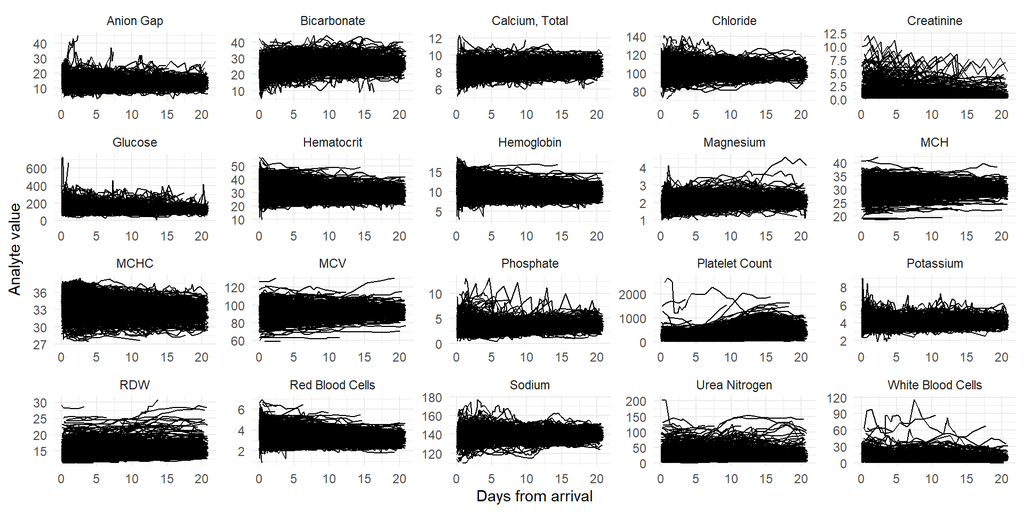

```r
## Spaghetti plot
mimic_modeling_set_f%>%
  ggplot(aes(time_days, value_clean))+
  geom_line(aes(group=subject_id))+
  facet_wrap(~label, scales = "free")+
  xlab("Days from arrival")+
  ylab("Analyte value")+
  theme_minimal()
```

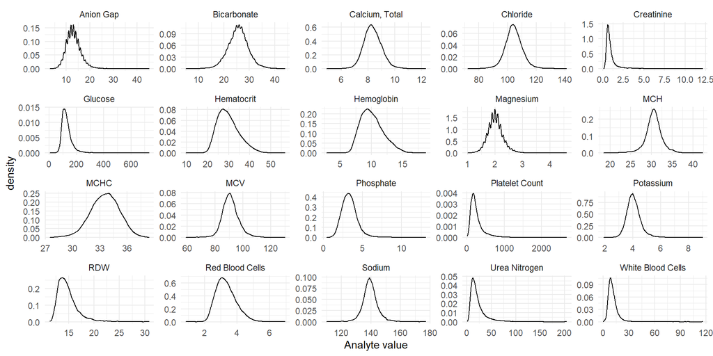

```r
ggsave("figures/modeling_set_labs_clean.png", height = 6, width = 10)

## Marginal density
mimic_modeling_set_f%>%
  ggplot(aes(value_clean))+
  geom_density()+
  facet_wrap(~label, scales = "free")+
  xlab("Analyte value")+
  theme_minimal()
```

```r
ggsave("figures/modeling_set_labs_clean_density.png", height = 6, width = 10)
```

## Final cohort

```r
mimic_patients_all<-mimic_patients_all%>%
  filter(subject_id%in%unique(mimic_labs_hadm_filter$subject_id))

length(unique(mimic_patients_all$subject_id))
```

```
## [1] 2615
```

```r
## Custom function for Exact fisher analysis with p.value simulation
my_fisher<-function(data,variable, by, conf.level, ...){
    data <- data[c(variable, by)] %>% dplyr::filter(complete.cases(.))
  fisher.test(data[[variable]], factor(data[[by]]), simulate.p.value = T) %>%
  broom::tidy()
}
```

### Demographics table

```r
mimic_patients_all%>%
  ungroup()%>%
  select(age, gender, insurance, ethnicity, dataset, cohort_group)%>%
  tbl_summary(by = cohort_group)%>%
  add_p(test = list(all_categorical() ~ "my_fisher"))%>%
  add_q()
```

| **Characteristic** | **SCI_Fracture**, N = 382<sup>1</sup> | **SCI_noFracture**, N = 125<sup>1</sup> | **Spine Trauma**, N = 2,108<sup>1</sup> | **p-value**<sup>2</sup> | **q-value**<sup>3</sup> |
| --- | --- | --- | --- | --- | --- |
| age | 55 (39, 71) | 57 (44, 72) | 65 (44, 81) | <0.001 | <0.001 |
| gender |  |  |  | <0.001 | <0.001 |
| F | 101 (26%) | 37 (30%) | 924 (44%) |  |  |
| M | 281 (74%) | 88 (70%) | 1,184 (56%) |  |  |
| insurance |  |  |  | 0.006 | 0.006 |
| Medicaid | 37 (9.7%) | 13 (10%) | 154 (7.3%) |  |  |
| Medicare | 118 (31%) | 48 (38%) | 865 (41%) |  |  |
| Other | 221 (58%) | 62 (50%) | 1,064 (50%) |  |  |
| Other Government | 6 (1.6%) | 2 (1.6%) | 25 (1.2%) |  |  |
| ethnicity |  |  |  | <0.001 | <0.001 |
| ASIAN | 6 (1.9%) | 0 (0%) | 43 (2.3%) |  |  |
| BLACK/AFRICAN AMERICAN | 14 (4.4%) | 23 (20%) | 88 (4.8%) |  |  |
| HISPANIC/LATINO | 14 (4.4%) | 9 (7.9%) | 77 (4.2%) |  |  |
| MULTI RACE/ETHNICITY | 1 (0.3%) | 0 (0%) | 5 (0.3%) |  |  |
| OTHER | 17 (5.4%) | 5 (4.4%) | 84 (4.6%) |  |  |
| WHITE | 264 (84%) | 77 (68%) | 1,540 (84%) |  |  |
| Unknown | 66 | 11 | 271 |  |  |
| dataset |  |  |  | <0.001 | <0.001 |
| MIMIC-III | 231 (60%) | 49 (39%) | 826 (39%) |  |  |
| MIMIC-IV | 151 (40%) | 76 (61%) | 1,282 (61%) |  |  |

<sup>*1*</sup> Median (IQR); n (%) <sup>*2*</sup> Kruskal-Wallis rank sum test; Fisher's Exact Test for Count Data with simulated p-value (based on 2000 replicates) <sup>*3*</sup> False discovery rate correction for multiple testing

### Stay characteristics

```r
mimic_patients_all%>%
  ungroup()%>%
  select(time_disch_days, admission_location, discharge_location, n_codes,cohort_group)%>%
  mutate(n_codes = as.numeric(n_codes))%>%
  tbl_summary(by = cohort_group)%>%
  add_p(test = list(all_categorical() ~ "my_fisher"))%>%
  add_q()
```

| **Characteristic** | **SCI_Fracture**, N = 382<sup>1</sup> | **SCI_noFracture**, N = 125<sup>1</sup> | **Spine Trauma**, N = 2,108<sup>1</sup> | **p-value**<sup>2</sup> | **q-value**<sup>3</sup> |
| --- | --- | --- | --- | --- | --- |
| time_disch_days | 11 (7, 19) | 8 (5, 13) | 7 (4, 11) | <0.001 | <0.001 |
| Unknown | 1 | 0 | 0 |  |  |
| admission_location |  |  |  | 0.076 | 0.10 |
| CLINIC REFERRAL | 55 (14%) | 22 (18%) | 251 (12%) |  |  |
| EMERGENCY ROOM | 301 (79%) | 89 (71%) | 1,730 (82%) |  |  |
| TRANSFER FROM HOSP | 20 (5.3%) | 12 (9.6%) | 95 (4.5%) |  |  |
| TRANSFER FROM SNF | 0 (0%) | 0 (0%) | 3 (0.1%) |  |  |
| WALK-IN/SELF REFERRAL | 4 (1.1%) | 2 (1.6%) | 20 (1.0%) |  |  |
| Unknown | 2 | 0 | 9 |  |  |
| discharge_location |  |  |  | <0.001 | <0.001 |
| ACUTE HOSPITAL | 4 (1.0%) | 0 (0%) | 9 (0.4%) |  |  |
| AGAINST ADVICE | 0 (0%) | 2 (1.6%) | 11 (0.5%) |  |  |
| DIED | 46 (12%) | 6 (4.9%) | 141 (6.9%) |  |  |
| HOME/HOSPICE | 56 (15%) | 46 (37%) | 687 (34%) |  |  |
| ICF | 1 (0.3%) | 0 (0%) | 0 (0%) |  |  |
| LONG TERM CARE | 22 (5.8%) | 5 (4.1%) | 88 (4.3%) |  |  |
| REHAB | 208 (54%) | 45 (37%) | 528 (26%) |  |  |
| SHORT TERM CARE | 3 (0.8%) | 0 (0%) | 8 (0.4%) |  |  |
| SKILLED NURSING FACILITY | 35 (9.2%) | 17 (14%) | 544 (27%) |  |  |
| TRANSFER TO OTHER | 7 (1.8%) | 2 (1.6%) | 29 (1.4%) |  |  |
| Unknown | 0 | 2 | 63 |  |  |
| n_codes | 13 (9, 18) | 13 (8, 21) | 14 (9, 20) | 0.10 | 0.10 |

<sup>*1*</sup> Median (IQR); n (%) <sup>*2*</sup> Kruskal-Wallis rank sum test; Fisher's Exact Test for Count Data with simulated p-value (based on 2000 replicates) <sup>*3*</sup> False discovery rate correction for multiple testing

# Modeling

```r
mimic_modeling_set_f<-mimic_modeling_set_f%>%
  ungroup()%>%
  filter(subject_id%in%unique(mimic_patients_all$subject_id))%>%
  mutate(subject_id_num=as.numeric(as.factor(subject_id)))

saveRDS(mimic_modeling_set_f, "data/mimic_modeling_set_f.Rds")
```

### LCGA: Initial exploratory modeling

The results for each model are saved in the *./models/* folder as `.Rds` files.

```
Note that the data for each model is not saved to prevent the data to be accessible through the .Rds files. These files contain all the elements of the fitted models.
```

**Not run on knitting time**

```r
mimic_modeling_set_f<-readRDS("mimic_modeling_set_f.Rds")
modeling_set_list<-split(mimic_modeling_set_f,mimic_modeling_set_f$label)

## Helper function
my_LCGA<-function(dataset, G=2:5){

  dataset<-as.data.frame(dataset)
  var_name<-dataset$label[1]

  ### initial 1 class model
  cat("Model: m1p1", "\n")

  file<-paste0("models/expLCGA_",var_name,"_linear_m1p1.Rds")
  if(!file%in%model_files){
    m1 <- lcmm(value_clean ~ time_days,random =~ 1,
               subject = 'subject_id_num', data = dataset,maxiter = 200)

    saveRDS(m1, file = file)
  } else{
    m1<-readRDS(file)
  }

  file<-paste0("models/expLCGA_",var_name,"_beta_m1p1.Rds")
  if(!file%in%model_files){
    m1_beta <- lcmm(value_clean ~ time_days,random =~ 1,
                    subject = 'subject_id_num',
                  data = dataset, link="beta",maxiter = 200)

    saveRDS(m1_beta, file = file)
  }else{
    m1_beta<-readRDS(file)
  }

  file<-paste0("models/expLCGA_",var_name,"_spline_m1p1.Rds")
  if(!file%in%model_files){
    m1_splines <- lcmm(value_clean ~ time_days,random =~ 1,
                       subject = 'subject_id_num',
                       data = dataset, link="3-quant-splines",maxiter = 200)

    saveRDS(m1_splines, file = file)
  }else{
    m1_splines<-readRDS(file)
  }

  cat("Model: m1p2", "\n")

  file<-paste0("models/expLCGA_",var_name,"_linear_m1p2.Rds")
  if(!file%in%model_files){
    m1p2 <- lcmm(value_clean ~ poly(time_days, 2),random =~ 1,
                 subject = 'subject_id_num', data = dataset,maxiter = 200)

    saveRDS(m1p2, file = file)
  }else{
    m1p2<-readRDS(file)
  }

  file<-paste0("models/expLCGA_",var_name,"_beta_m1p2.Rds")
  if(!file%in%model_files){
    m1p2_beta <- lcmm(value_clean ~ poly(time_days, 2),random =~ 1,
                 subject = 'subject_id_num', data = dataset,
                 link = "beta",maxiter = 200)

    saveRDS(m1p2_beta, file = file)
  }else{
    m1p2_beta<-readRDS(file)
  }

  file<-paste0("models/expLCGA_",var_name,"_splines_m1p2.Rds")
  if(!file%in%model_files){
    m1p2_splines <- lcmm(value_clean ~ poly(time_days, 2),random =~ 1,
                 subject = 'subject_id_num', data = dataset,
                 link = "3-quant-splines",maxiter = 200)

    saveRDS(m1p2_splines, file = file)
  }else{
    m1p2_splines<-readRDS(file)
  }

  cat("Model: m1p3", "\n")

  file<-paste0("models/expLCGA_",var_name,"_linear_m1p3.Rds")
  if(!file%in%model_files){
    m1p3 <- lcmm(value_clean ~ poly(time_days, 3),random =~ 1,
               subject = 'subject_id_num', data = dataset,maxiter = 200)

    saveRDS(m1p3, file = file)
  }else{
    m1p3<-readRDS(file)
  }

  file<-paste0("models/expLCGA_",var_name,"_beta_m1p3.Rds")
  if(!file%in%model_files){
    m1p3_beta <- lcmm(value_clean ~ poly(time_days, 3),random =~ 1,
               subject = 'subject_id_num', data = dataset,
               link = "beta",maxiter = 200)

    saveRDS(m1p3_beta, file = file)
  }else{
    m1p3_beta<-readRDS(file)
  }

  file<-paste0("models/expLCGA_",var_name,"_splines_m1p3.Rds")
  if(!file%in%model_files){
    m1p3_splines <- lcmm(value_clean ~ poly(time_days, 3),random =~ 1,
               subject = 'subject_id_num', data = dataset,
               link = "3-quant-splines",maxiter = 200)

    saveRDS(m1p3_splines, file = file)
  }else{
    m1p3_splines<-readRDS(file)
  }


  for (k in G){
    cat("Model: k",k,"p1", "\n")

    file<-paste0("models/expLCGA_",var_name,"_linear_k",k,"p1.Rds")
    if(!file%in%model_files){
      temp_k <- lcmm(value_clean ~ time_days,random =~ 1,
                     subject = 'subject_id_num',
               data = dataset, mixture = ~time_days,
               ng = k, B = m1,maxiter = 200)

      saveRDS(temp_k, file = file)
    }

    file<-paste0("models/expLCGA_",var_name,"_beta_k",k,"p1.Rds")
    if(!file%in%model_files){
      temp_k_beta <- lcmm(value_clean ~ time_days,random =~ 1,
                          subject = 'subject_id_num',
                          data = dataset, mixture = ~time_days,
                          ng = k, B = m1_beta, link = "beta",maxiter = 200)

      saveRDS(temp_k_beta, file = file)
    }

    file<-paste0("models/expLCGA_",var_name,"_splines_k",k,"p1.Rds")
    if(!file%in%model_files){
      temp_k_splines <- lcmm(value_clean ~ time_days,random =~ 1,
                             subject = 'subject_id_num',
                             link = "3-quant-splines",
               data = dataset, mixture = ~time_days, ng = k,
               B = m1_splines,maxiter = 200)

      saveRDS(temp_k_splines, file = file)
    }

    cat("Model: k",k,"p2", "\n")

    file<-paste0("models/expLCGA_",var_name,"_linear_k",k,"p2.Rds")
    if(!file%in%model_files){
      temp_kp2 <- lcmm(value_clean ~ poly(time_days, 2),random =~ 1,
                                subject = 'subject_id_num',
               data = dataset, mixture = ~poly(time_days, 2),
               ng = k, B = m1p2,maxiter = 200)

      saveRDS(temp_kp2, file = file)
    }

    file<-paste0("models/expLCGA_",var_name,"_beta_k",k,"p2.Rds")
    if(!file%in%model_files){
      temp_kp2_beta <- lcmm(value_clean ~ poly(time_days, 2),random =~ 1,
                                subject = 'subject_id_num',
               data = dataset, mixture = ~poly(time_days, 2),
               ng = k, B = m1p2_beta, link = "beta",maxiter = 200)

      saveRDS(temp_kp2_beta, file = file)
    }

    file <- paste0("models/expLCGA_",var_name,"_splines_k",k,"p2.Rds")
    if(!file%in%model_files){
      temp_kp2_splines <- lcmm(value_clean ~ poly(time_days, 2),random =~ 1,
                                subject = 'subject_id_num',
               data = dataset, mixture = ~poly(time_days, 2),
               ng = k, B = m1p2_splines, link = "3-quant-splines",
               maxiter = 200)

      saveRDS(temp_kp2_splines, file = file)
    }

    cat("Model: k",k,"p3", "\n")

    file<-paste0("models/expLCGA_",var_name,"_linear_k",k,"p3.Rds")
    if(!file%in%model_files){
      temp_kp3 <- lcmm(value_clean ~ poly(time_days, 3),
                                  random =~ 1, subject = 'subject_id_num',
               data = dataset,
               mixture = ~poly(time_days, 3),ng = k,
               B = m1p3,maxiter = 200)

      saveRDS(temp_kp3, file = file)
    }

    file<-paste0("models/expLCGA_",var_name,"_beta_k",k,"p3.Rds")
    if(!file%in%model_files){
      temp_kp3_beta <- lcmm(value_clean ~ poly(time_days, 3),
                                  random =~ 1, subject = 'subject_id_num',
               data = dataset, link = "beta",
               mixture = ~poly(time_days, 3),ng = k,
               B = m1p3_beta,maxiter = 200)

      saveRDS(temp_kp3_beta, file = file)
    }

    file<-paste0("models/expLCGA_",var_name,"_splines_k",k,"p3.Rds")
    if(!file%in%model_files){
      temp_kp3_splines <- lcmm(value_clean ~ poly(time_days, 3),
                                  random =~ 1, subject = 'subject_id_num',
               data = dataset, link = "3-quant-splines",
               mixture = ~poly(time_days, 3),ng = k,
               B = m1p3_splines,maxiter = 200)

      saveRDS(temp_kp3_splines, file = file)
    }
  }
}


## Iterate through all the analytes by parallelyzing
cl<-makeCluster(15)
model_files<-list.files("models/", full.names = T)
clusterExport(cl, c("my_LCGA", "modeling_set_list", "model_files"))
clusterEvalQ(cl, library(lcmm))

parLapply(cl, 1:20, fun = function(a){
  my_LCGA(modeling_set_list[[a]])
})

stopCluster(cl)
```

**Read the files and process them**

```r
model_files<-list.files("models/", full.names = T)

lab_names<-unique(str_split(model_files, "_", simplify = T)[,2])
models_list<-list()

## Read all the models in a list of lists
for (l in lab_names){
  temp_list<-list()
  for (f in model_files){
    if (str_split(f, "_", simplify = T)[,2]==l){
      temp_list[[f]]<-readRDS(f)
    }
  }

  models_list[[l]]<-temp_list
}

saveRDS(models_list, "models/models_list.Rds")
```

The following function extracts the model selection metrics for each analyte

```r
model_metrics<-function(lab_name, models_list){

    lab_list<-models_list[[lab_name]]

    table_m_selection_l<-mapply(function(x, i){
      temp_x<-as.data.frame(summarytable(x, which = c("G", "conv", "npm", "AIC",
                                        "BIC", "entropy","ICL", "%class")))

      for (c in c("%class2", "%class3", "%class4", "%class5")){
        if (!c%in%colnames(temp_x)){
          temp_x[,c]<-NA
        }
      }

      if( temp_x[1,]$G != 1){
        pprob<-x$pprob
        pprob$PPA<-apply(pprob[,3:ncol(pprob)], 1, max)
        temp_x$APPA = mean(pprob$PPA)
      }else{
        temp_x$APPA = 1
      }


      modeltype<-str_split(i, "_", simplify = T)[,4]

      temp_x$analyte<-lab_name
      temp_x$linktype<-str_split(i, "_", simplify = T)[,3]
      temp_x$modeltype<-str_sub(modeltype, 1, 4)
      temp_x$poly = str_sub(modeltype, 3,4)

      temp_x

    }, lab_list, names(lab_list), SIMPLIFY = F)


    table_m_selection<-bind_rows(table_m_selection_l)

    table_m_selection<-table_m_selection%>%
      mutate(linktype = ifelse(linktype == "splines", "spline", linktype),
             linktype = factor(linktype, levels = c("linear", "beta", "spline")))

    table_m_selection_plot<-table_m_selection%>%
      filter(conv %in% c(1,2))%>%
      select(G, BIC, ICL, APPA, poly, linktype)%>%
      pivot_longer(-c(G, poly, linktype))%>%
      mutate(name = factor(name, levels = c("BIC", "ICL", "APPA")))

   figure<-ggplot(table_m_selection_plot, aes(G, value, color = poly,
                                       shape = linktype, linetype = linktype))+
      geom_point()+
      geom_line()+
      facet_wrap(~name, scales = "free")+
      xlab("Number of classes")+
      ylab(NULL)+
      theme_minimal()+
      ggtitle(unique(table_m_selection$analyte))

    return(list("lab_name" = lab_name, "table"= table_m_selection,
                "fig" = figure))
}
```

The following chunks extract the model metrics and save the LCGA plots

```r
# models_list<-readRDS("data/models_list.Rds")

model_selection_list<-list()
for (l in lab_names){
  model_selection_list[[l]]<-model_metrics(l, models_list)
}
```

```r
LCGA_plots<-lapply(model_selection_list, function(x){
  ggsave(plot = x$fig, paste0("figures/LCGA fit plots/LCGA_", x$lab_name, ".png"), width = 8, height = 2.6)
  x$fig
})

# saveRDS(LCGA_plots, "figures/LCGA_plots.Rds")
```

#### LCGA summaries

**Summary Plots**

```r
hematology_var<-summary_labs%>%filter(category == "Hematology", fluid =="Blood",
                                      label %in%lab_names)%>%.$label

chemistry_var<-summary_labs%>%filter(category == "Chemistry", fluid =="Blood",
                                      label %in% lab_names)%>%
  .$label

LCGA_fig_hem<-wrap_plots(LCGA_plots[hematology_var])+plot_layout(guides = "collect",ncol = 2)+plot_annotation(tag_levels = "a")

ggsave(plot = LCGA_fig_hem, "figures/LCGA_fig_hem.png", width = 12, height = 12)

LCGA_fig_chem<-wrap_plots(LCGA_plots[chemistry_var])+plot_layout(guides = "collect",ncol = 2)+plot_annotation(tag_levels = "a")

ggsave(plot = LCGA_fig_chem, "figures/LCGA_fig_chem.png", width = 12, height = 14)
```

**Summary Tables**

```r
lapply(model_selection_list, function(x){
  x$table%>%
    arrange(G, linktype,npm, poly)%>%
    select(G, conv, linktype,npm, poly, BIC, ICL, APPA, `%class1`, `%class2`,
           `%class3`, `%class4`, `%class5`)%>%
    rowwise()%>%
    mutate(across(.cols = c("BIC", "ICL", "APPA", "%class1", "%class2",
           "%class3", "%class4", "%class5"), .fns = function(x){
             if(!conv%in%c(1,2)) NA else x
           }))%>%
    select(-conv)%>%
    kableExtra::kbl(row.names = F,digits = 2)%>%
    kable_styling(full_width = F)%>%
    kable_classic()%>%
    kableExtra::save_kable(file = paste0("tables/LCGA fit tables/LCGA_",
                                         x$lab_name, ".html"))
})
```

### GMM: model search

This section reads the selected model parameters from the LCGA exploration and fit selected GMM models. As before, this is computationally expensive and was done through paralellization.

```r
GMM_param<-read.csv("GMM_param.csv")
colnames(GMM_param)[1]<-"analyte"

my_GMM<-function(analyte, link, k, d){

  ## Custom function for the fitting of the GMM models based on the provided parameters
  ## @ analyte: string with the name of the analyte
  ## @ link: string with the name of the link function
  ## @ k: number of classes to fit
  ## @ d: degree of the polynomial for the time trend

  # analyte<-"Glucose"
  dataset<-as.data.frame(modeling_set_list[[analyte]])

  file<-paste0("models_GMM/GMM_",analyte,"_", link, "_m",k,"p",d,".Rds")

  if (d == 1){
    model_form<-"value_clean ~ time_days"
    random<-"~ time_days"
  }else{
    model_form<-paste0("value_clean ~ splines::ns(time_days,",d,")")
    random<-paste0("~ splines::ns(time_days,",d,")")
  }

  if (k == 1){
      if(!file%in%model_files){

        sink("test.txt",append = T)
          cat(Sys.time(),analyte, link, k, d,"\n")
        sink()

        m1 <- lcmm(as.formula(model_form),random =as.formula(random),
                   subject = 'subject_id_num', data = dataset,link = link,
                   maxiter = 2000)

              saveRDS(m1, file = file)
      }
  }else{


    error<-try(
      m1<-readRDS(paste0("models_GMM/GMM_",analyte,"_",
                         link, "_m1p",d,".Rds"))
    )

    if (class(error) == "try_error"){
        sink("test.txt",append = T)
          cat(Sys.time(), analyte, link, k, d,"\n")
        sink()
    }

    if(!file%in%model_files){

        sink("test.txt",append = T)
          cat(Sys.time(), analyte, link, k, d,"\n")
        sink()

        m2 <- lcmm(as.formula(model_form),random =as.formula(random),
                   subject = 'subject_id_num', data = dataset,link = link,
                   ng =k, mixture = as.formula(random), B = m1,
                   maxiter = 2000)

              saveRDS(m2, file = file)
      }
  }
}
```

**Not run during Knitting**

```r
model_files<-list.files("models_GMM/", full.names = T)
GMM_param<-GMM_param%>%
  arrange(k)

cl<-makeCluster(15)
clusterExport(cl, c("modeling_set_list", "GMM_param", "my_GMM","model_files"))
clusterEvalQ(cl, library(lcmm))
clusterEvalQ(cl, library(splines))

parLapply(cl, 1:nrow(GMM_param), function(i){
  my_GMM(GMM_param[i,1], GMM_param[i,3], GMM_param[i,2],GMM_param[i,4])
})

stopCluster(cl)
```

**Read the files and process them**

```r
model_files<-list.files("models_GMM/", full.names = T)

## Read all the models in a list of lists
model_GMM_list<-lapply(model_files, readRDS)
names(model_GMM_list) <- model_files
```

The following chunk extracts the summary metrics for model selection

```r
model_selection_GMM_list<-mapply(function(x, i){

  temp_x<-as.data.frame(summarytable(x, which = c("G", "conv", "npm", "AIC",
                                        "BIC", "entropy","ICL", "%class")))

      for (c in c("%class2", "%class3", "%class4", "%class5")){
        if (!c%in%colnames(temp_x)){
          temp_x[,c]<-NA
        }
      }

      if( temp_x[1,]$G != 1){
        pprob<-x$pprob
        pprob$PPA<-apply(pprob[,3:ncol(pprob)], 1, max)
        temp_x$APPA = mean(pprob$PPA)
      }else{
        temp_x$APPA = 1
      }

      modeltype<-str_split(i, "_", simplify = T)[,5]

      temp_x$analyte<-str_split(i, "_", simplify = T)[,3]
      temp_x$linktype<-str_split(i, "_", simplify = T)[,4]
      temp_x$modeltype<-str_sub(modeltype, 1, 4)
      temp_x$poly = str_sub(modeltype, 3,4)

      temp_x

    }, model_GMM_list, names(model_GMM_list), SIMPLIFY = F)

model_selection_GMM_df<-do.call(rbind, model_selection_GMM_list)
model_selection_GMM_list <- split(model_selection_GMM_df, model_selection_GMM_df$analyte)

GMM_plots<-lapply(model_selection_GMM_list, function(x){
    table_m_selection<-x%>%
      as.data.frame(.)%>%
      mutate(linktype = ifelse(linktype == "3-quant-splines", "spline", linktype),
             linktype = factor(linktype, levels = c("linear", "beta", "spline")))

    table_m_selection_plot<-table_m_selection%>%
      filter(conv %in% c(1,2))%>%
      select(G, BIC, ICL, APPA, poly, linktype)%>%
      pivot_longer(-c(G, poly, linktype))%>%
      mutate(name = factor(name, levels = c("BIC", "ICL", "APPA")))

   figure<-ggplot(table_m_selection_plot, aes(G, value, color = poly,
                                       shape = linktype, linetype = linktype))+
      geom_point()+
      geom_line()+
      facet_wrap(~name, scales = "free")+
      xlab("Number of classes")+
      ylab(NULL)+
      theme_minimal()+
      ggtitle(unique(table_m_selection$analyte))

   ggsave(plot = figure, paste0("figures/GMM fit plots/GMM_", unique(table_m_selection$analyte), ".png"), width = 8, height = 2.6)

   figure
})
```

#### GMM summaries

**Summary Plots**

```r
GMM_fig_hem<-wrap_plots(GMM_plots[hematology_var])+plot_layout(guides = "collect",ncol = 2)+plot_annotation(tag_levels = "a")

ggsave(plot = GMM_fig_hem, "figures/GMM_fig_hem.png", width = 12, height = 12)

GMM_fig_chem<-wrap_plots(GMM_plots[chemistry_var])+plot_layout(guides = "collect",ncol = 2)+plot_annotation(tag_levels = "a")

ggsave(plot = GMM_fig_chem, "figures/GMM_fig_chem.png", width = 12, height = 14)
```

**Summary Tables**

```r
model_selection_GMM_df%>%
    arrange(analyte, G, linktype,npm, poly)%>%
    select(analyte, G, conv, linktype,npm, poly, BIC, ICL, APPA, `%class1`, `%class2`,
           `%class3`, `%class4`, `%class5`)%>%
    rowwise()%>%
    mutate(across(.cols = c("BIC", "ICL", "APPA", "%class1", "%class2",
           "%class3", "%class4", "%class5"), .fns = function(x){
             if(!conv%in%c(1,2)) NA else x
           }))%>%
    select(-conv)%>%
    kableExtra::kbl(row.names = F,digits = 2)%>%
    kable_styling(full_width = F)%>%
    kable_classic()%>%
    kableExtra::save_kable(file = "tables/GMM fit tables/GMM_table.html")
```

## GMM: final models

```r
files_GMM_selected<-list.files("model_GMM_selected/", full.names = T)

GMM_list<-lapply(files_GMM_selected, readRDS)
names(GMM_list)<-files_GMM_selected

GMM_list<-mapply(function(x, i){
  d <- str_split(i, "_", simplify = T)[,6]
  k <- str_sub(d, 2,2)
  d <- str_sub(d, 4,4)
  link <- str_split(i, "_", simplify = T)[,5]

  if (d ==1){
    model_form<-paste0("value_clean ~ time_days")
    random<-paste0("~ time_days")
  }else{
    model_form<-paste0("value_clean ~ splines::ns(time_days,",d,")")
    random<-paste0("~ splines::ns(time_days,",d,")")
  }

  x$call$fixed<-as.formula(model_form)
  x$call$random<-as.formula(random)
  x$call$mixture<-as.formula(random)
  x$call$link<-link
  x$call$ng<-as.numeric(k)

  return(x)

}, GMM_list, names(GMM_list), SIMPLIFY = F)
```

#### Plotting trajectories

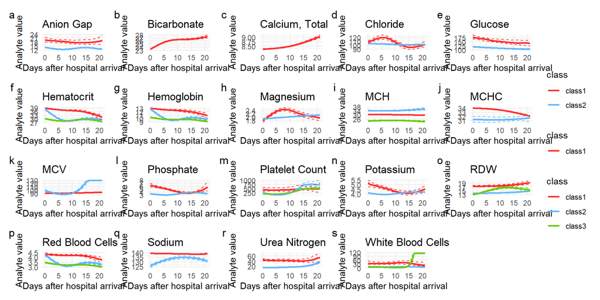

```r
new_dataset<-data.frame(time_days = seq(0,21,length.out = 100))

plot_GMM<-function(gmm_model, analyte, k){

  gmm_model$call$data<-new_dataset
  pred<-predictY(gmm_model, new_dataset, draws = T, ndraws = 100)

  if(gmm_model$conv ==1){
    if(k == 1){
      pred_df<-do.call(cbind, pred)%>%
      pivot_longer(-time_days)%>%
      mutate(class = "class1",
         quantile = str_split (name, "_", simplify = T)[,2])
    }else{
      pred_df<-do.call(cbind, pred)%>%
      pivot_longer(-time_days)%>%
      mutate(class = str_split(name, "_", simplify = T)[,3],
         quantile = str_split (name, "_", simplify = T)[,2])
    }

    p<-pred_df%>%
    filter(quantile == 50)%>%
    ggplot(aes(time_days, value, color = class, group = class))+
    geom_path(size = 1)+
    geom_path(data = pred_df%>%filter(quantile == 2.5), linetype = "dashed")+
    geom_path(data = pred_df%>%filter(quantile == 97.5), linetype = "dashed")+
    scale_color_manual(values = c("firebrick1","steelblue1", "chartreuse3"))+
    xlab("Days after hospital arrival")+
    ylab("Analyte value")+
    theme_minimal()+
          ggtitle(analyte)
  }else{
    pred_df<-do.call(cbind, pred)%>%
      pivot_longer(-time_days)%>%
      mutate(class = str_split(name, "_", simplify = T)[,2])

    p<-pred_df%>%
    ggplot(aes(time_days, value, color = class, group = class))+
    geom_path(size = 1)+
    xlab("Days after hospital arrival")+
    ylab("Analyte value")+
    scale_color_manual(values = c("firebrick1","steelblue1", "chartreuse3"))+
    theme_minimal()+
                ggtitle(analyte)
  }

  return(p)
}

GMM_plots<-mapply(function(x, i){
  analyte<-str_split(i, "_", simplify = T)[,4]
  k <- str_split(i, "_", simplify = T)[,6]
  k <- str_sub(k, 2,2)

  plot_GMM(x, analyte,k)
}, GMM_list, names(GMM_list), SIMPLIFY = F)

GMM_fig_traj<-wrap_plots(GMM_plots)+plot_layout(guides = "collect",ncol = 5)+plot_annotation(tag_levels = "a")

GMM_fig_traj
```

```r
ggsave(plot = GMM_fig_traj, "figures/GMM_fig_traj.png", width = 14, height = 10)
```

#### Trajectory description

Preparation of the class probability

```r
class_GMM_list<-mapply(function(x, i){
  pprob<-x$pprob
  if(ncol(pprob) == 4){
    pprob$prob3<-NA
  }else if(ncol(pprob) ==3){
    pprob$prob2<-NA
    pprob$prob3<-NA
  }
  pprob$analyte<-str_split(i, "_", simplify = T)[,4]

  return(pprob)
}, GMM_list, names(GMM_list), SIMPLIFY = F)

class_GMM_df<-do.call(rbind, class_GMM_list)

subject_id_df<-mimic_modeling_set_f%>%
  select(subject_id, subject_id_num)%>%
  group_by(subject_id)%>%
  summarise(subject_id_num = unique(subject_id_num))

class_GMM_df<-class_GMM_df%>%
  left_join(subject_id_df)%>%
  left_join(mimic_patients_all)%>%
  filter(!analyte %in%c("Bicarbonate", "Calcium, Total", "Creatinine"))
```

Tables of univariate analysis between classes per analyte

```r
class_GMM_df<-class_GMM_df%>%
  mutate(n_codes = as.numeric(n_codes))
```

```r
lapply(unique(class_GMM_df$analyte), function(x){
  class_GMM_df%>%
    filter(analyte == x)%>%
    select(class, age, gender,ethnicity ,cohort_group, time_disch_days,
           hospital_expire_flag, n_codes)%>%
    tbl_summary(by=class)%>%
    add_p(test = list(all_numeric()~"aov",all_categorical() ~ "my_fisher"))%>%
    add_q()%>%
    as_kable()%>%
    kable_paper()%>%
    save_kable(file = paste("tables/class_diff_", x,".html"))

})
```

### Group-Based Multi-trajectory Analysis (GBMT)

In this work we also explored the idea of GBMT modeling for analytes. Given that most analytes correlate and this is a proof of concept, we kept this to just a subset of the modeling set of analytes.

Similar than LCGA and GMM, we did a linear search of the parameter space and run the models through parallelization. To simplify the models further, we binned data by days by taking the average. Most patients had one value a day, so in most situations, the binning is just setting the time component to integer of a day instead of fractional days.

```r
## Bin by day
mimic_modeling_set_f_bin<-mimic_modeling_set_f%>%
  filter(label%in%c("Hematocrit", "Glucose", "White Blood Cells","RDW", "Platelet Count"))%>%
  mutate(time_days = ceiling(time_days))%>%
  group_by(subject_id, label,time_days)%>%
  summarise(value_clean = mean(value_clean, na.rm = T))

mimic_modeling_set_f_wide<-mimic_modeling_set_f_bin%>%
  pivot_wider(c(subject_id, time_days), names_from = label, values_from = value_clean,values_fn = function(x) mean(x, na.rm =T))%>%
  as.data.frame(.)

colnames(mimic_modeling_set_f_wide)<-make.names(colnames(mimic_modeling_set_f_wide))

pd<-1:4 ## polynomial degrees for the search
ng<-1:8 ## number of classes for the search
param<-expand.grid(pd, ng)

cl<-makeCluster(15)
clusterExport(cl, c("mimic_modeling_set_f_wide", "param"))
clusterEvalQ(cl, library(gbmt))

parLapply(cl, 1:nrow(param), function(x){

  temp_pd<-param[x,1]
  temp_ng<-param[x,2]

  temp_gbmt<-gbmt(data = mimic_modeling_set_f_wide,
           x.names = colnames(mimic_modeling_set_f_wide)[3:7],
           unit = "subject_id",
           time = "time_days", ng = temp_ng, d = temp_pd)

  saveRDS(temp_gbmt, paste0("model_gbmt/gbmt_",
                            temp_ng, "_", temp_pd,".RDS"))
})

stopCluster(cl)
```

#### GBMT summaries

Read the saved models and extract summaries

```r
model_gbmt_files<-list.files("model_gbmt/", full.names = T)
gbmt_list<-lapply(model_gbmt_files, function(x){
  list("model" = readRDS(x), "file" = x)
})

model_summary_gbmt<-function(model_list){

  model<-model_list$model
  ng<-str_split(model_list$file, "_", simplify = T)[,3]

  ## Get proportion of class assignment
  class_assignment<-as.data.frame(prop.table(table(model$assign)))[,2]
  class_assignment<-matrix(round(class_assignment*100, 2),
                           ncol = length(class_assignment))

  colnames(class_assignment)<-paste0("%class", 1:ncol(class_assignment))

  for (c in paste0("%class", 2:8)){
        if (!c%in%colnames(class_assignment)){
          class_assignment<-cbind(class_assignment, c = NA)
        }
  }

  colnames(class_assignment)<-paste0("%class", 1:ncol(class_assignment))

  table_summary<-data.frame(k = ng, poly = paste0("p",model$call$d),
                npar = model$npar, BIC = BIC(model), APPA = mean(model$appa))
  table_summary<-cbind(table_summary, as.data.frame(class_assignment))

  return(table_summary)
}

gbmt_summaries<-lapply(gbmt_list, model_summary_gbmt)
gbmt_summaries<-do.call(rbind,gbmt_summaries)
```

**Model selection summary table**

```r
gbmt_summaries%>%
  kable(digits = 2)%>%
  kable_paper()%>%
  save_kable(file = "tables/gbmt_summary.html")
```

**Model selection summary plots**

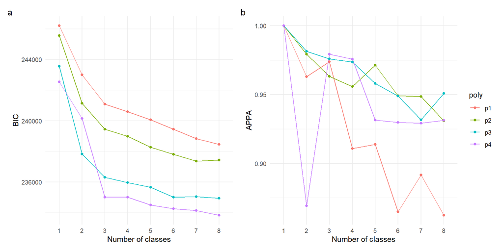

```r
gbmt_plot_a<-gbmt_summaries%>%
  ggplot(aes(k, BIC, color = poly, group = poly))+
    geom_line()+
    geom_point()+
  xlab("Number of classes")+
  theme_minimal()

gbmt_plot_b<-gbmt_summaries%>%
  ggplot(aes(k, APPA, color = poly, group = poly))+
    geom_line()+
    geom_point()+
  xlab("Number of classes")+
  theme_minimal()

fig_gbmt<-gbmt_plot_a + gbmt_plot_b + plot_layout(guide = "collect")+ plot_annotation(tag_levels = "a")

fig_gbmt
```

```r
ggsave(fig_gbmt, filename = "figures/fig_gbmt_summary.png", width = 8, height = 3)
```

#### Final GBMT model

Final selected model

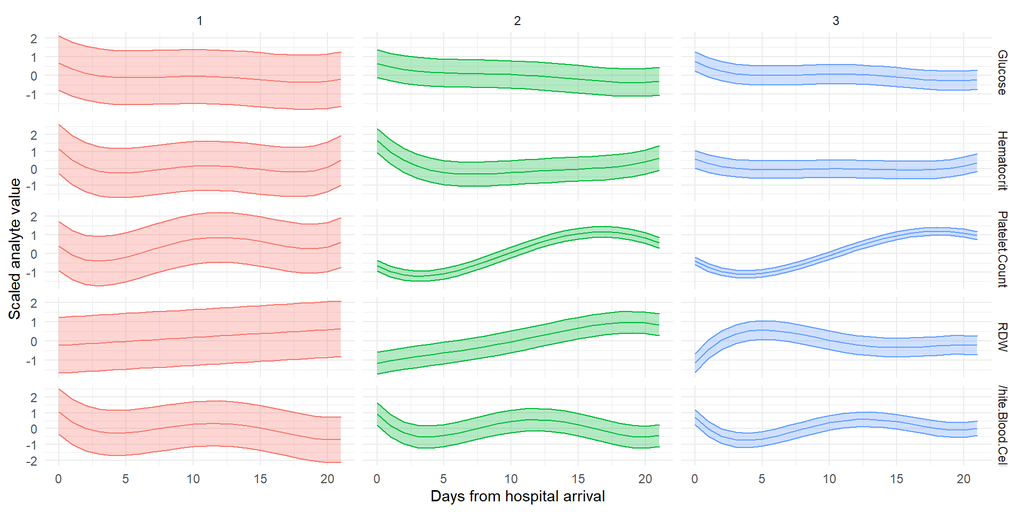

```r
gbmt_selected<-gbmt_list[[12]]

gbmt_to_plot<-gbmt:::predict.gbmt(gbmt_selected$model)
gbmt_to_plot<-mapply(function(x, i){
  level_2<-mapply(function(y, j, i){
    y<-as.data.frame(y)
    y$analyte<-j
    y$class <- i
    y$time_days <-0:21
    return(y)
  },x, names(x), i,SIMPLIFY = F)

  do.call(rbind, level_2)
}, gbmt_to_plot, names(gbmt_to_plot), SIMPLIFY = F)

gbmt_to_plot<-gbmt_to_plot%>%bind_rows()

gbmt_final_plot<-ggplot(gbmt_to_plot, aes(time_days, mean, color = class, fill = class))+
  geom_line(show.legend = F)+
  geom_ribbon(aes(ymin = `2.5%`, ymax = `97.5%`), alpha = 0.3, show.legend = F)+
  facet_grid(analyte~class, scales = "free")+
  xlab("Days from hospital arrival")+
  ylab("Scaled analyte value")+
  theme_minimal()

gbmt_final_plot
```

```r
ggsave(gbmt_final_plot, filename = "figures/gbmt_final.png", height = 6, width = 6)
```

**Univariate analysis between classes**

```r
gbmt_ppost<-as.data.frame(gbmt_selected$model$posterior)
colnames(gbmt_ppost)<-c("ppost_1", "ppost_2", "ppost_3")

gbmt_ppost$subject_id<-rownames(gbmt_ppost)

class_name<-c("Class 1", "Class 2", "Class 3")
for (i in 1:nrow(gbmt_ppost)){
  gbmt_ppost$class[i]<-class_name[which.max(gbmt_ppost[i,1:3])]
}

class_GBMT_df<-gbmt_ppost%>%
  left_join(subject_id_df)%>%
  left_join(mimic_patients_all)%>%
  mutate(n_codes = as.numeric(n_codes))

class_GBMT_df%>%
    select(class, age, gender,ethnicity ,cohort_group, time_disch_days,
           hospital_expire_flag, n_codes)%>%
    tbl_summary(by=class)%>%
    add_p(test = list(all_numeric()~"aov",all_categorical() ~ "my_fisher"))%>%
    add_q()%>%
    as_kable()%>%
    kable_paper()%>%
    save_kable(file = "tables/class_diff_GBMT.html")
```

# Prediction Experiments

The following script sets custom functions to run the prediction experiments

```r
#for extracting prediction performance
pred_performance<-function(fit, X, Y, positive = "yes", negative = "no", roc = TRUE, roc_smooth = TRUE){
  prediction<-predict(fit, X, type = "prob")

  if(roc){
    r_curve<-pROC::roc(Y,prediction[,positive], smooth = roc_smooth)
  }else{
    r_curve = FALSE
  }

  class_prediction<-as.factor(ifelse(prediction[,positive]>0.5, positive, negative))
  c_matrix<-confusionMatrix(class_prediction, Y, positive = positive)

  return(list("fit" = fit, "pred" = prediction,
                            "class" = class_prediction, "roc"=r_curve,
                            "cMatrix" = c_matrix))
}

# to run the experiments I and II
run_experiment<-function(prediction_df, target.name, predictor_start = 3,
                         seed = 555, reps = 25,
                         n.yes.train, n.no.train, roc_smooth = TRUE){
  set.seed(seed)


  yes_class<-prediction_df%>%
    filter(!!sym(target.name) == "yes")
  yes_index<-sample(1:nrow(yes_class), n.yes.train, replace = F)
  yes_train_df<-yes_class[yes_index, ]
  yes_test_df<-yes_class[-yes_index, ]

  no_class<-prediction_df%>%
    filter(!!sym(target.name) == "no")
  no_index<-sample(1:nrow(no_class), n.no.train, replace = F)
  no_train_df<-no_class[no_index, ]
  no_test_df<-no_class[-no_index, ]

  ## Testing data preparation
  test_df<-rbind(yes_test_df, no_test_df)
  dmy <- dummyVars(" ~ .", data = test_df[,predictor_start:ncol(test_df)])

  X_test <- data.frame(predict(dmy, newdata = test_df))
  Y_test<-as.factor(unlist(test_df[,target.name]))

  ## Training with downsampling and repeated model building
  exp_fit_list<-list()
  for (i in 1:reps){
    print(i)
    temp_train_df<-rbind(yes_train_df, no_train_df)
    train_index<-tapply(1:nrow(temp_train_df),
                            INDEX = temp_train_df[,target.name],
                            FUN = function(x) sample(x, n.yes.train, replace = F))

    train_df<-temp_train_df[unlist(train_index),
                            predictor_start:ncol(temp_train_df)]
    dmy <- dummyVars(" ~ .", data = train_df)
    X <- data.frame(predict(dmy, newdata = train_df))
    Y<-as.factor(unlist(temp_train_df[unlist(train_index), target.name]))

    fit<-train( x = X, y = Y, method = "glmnet",
                trControl = trainControl(method = "cv", number = 5,
                                         classProbs = TRUE))

    exp_fit_list[[i]]<-pred_performance(fit, X, Y, roc_smooth =roc_smooth)
  }

  exp_test_fit<-lapply(exp_fit_list, function(x){
    pred_performance(x$fit, X_test, Y_test,roc_smooth = roc_smooth)
  })

  ## In-training prediction performance
  in_train_r_curve<-lapply(exp_fit_list, function(x){
    data.frame(sens = x$roc$sensitivities, spec = x$roc$specificities,
               pre_type = "in-train")
  })

  for(i in 1:length(in_train_r_curve)){
    in_train_r_curve[[i]]$id<-i
  }

  in_train_r_curve<-do.call(rbind, in_train_r_curve)

  ## out-train prediction performance
  out_train_r_curve<-lapply(exp_test_fit, function(x){
    data.frame(sens = x$roc$sensitivities, spec = x$roc$specificities,
               pre_type = "out-train")
  })

  for(i in 1:length(out_train_r_curve)){
    out_train_r_curve[[i]]$id<-i
  }

  out_train_r_curve<-do.call(rbind, out_train_r_curve)
  r_curve<-rbind(in_train_r_curve, out_train_r_curve)

  line_df<-data.frame(x = c(0,1), y = c(0,1))
  roc_plot<-ggplot(r_curve, aes(1-spec, sens, color =  pre_type, group = id))+
    geom_path(alpha = 0.3)+
    geom_line(data = line_df, aes(x, y), inherit.aes = F)+
    theme_minimal()

  return(list("train_list" = exp_fit_list, "test_list" = exp_test_fit,
              "roc_plot" = roc_plot))
}
```